# P1: Test a Perceptual Phenomenon

Statistics: The Science of Decisions Project Instructions

## Background Information

In a Stroop task, participants are presented with a list of words, with each word displayed in a color of ink. The participant’s task is to say out loud the color of the ink in which the word is printed. The task has two conditions: a congruent words condition, and an incongruent words condition. In the congruent words condition, the words being displayed are color words whose names match the colors in which they are printed: for example RED, BLUE. In the incongruent words condition, the words displayed are color words whose names do not match the colors in which they are printed: for example PURPLE, ORANGE. In each case, we measure the time it takes to name the ink colors in equally-sized lists. Each participant will go through and record a time from each condition.

#### 1. What is our independent variable? What is our dependent variable?

Independent variable is the type of Stroop task being performed (congruent or incongruent). Dependent variable is the time it took participant to perform each part of the Stroop tasks.

#### 2. What is an appropriate set of hypotheses for this task? What kind of statistical test do you expect to perform? Justify your choices.

H_0: Population mean time to complete incongruent task = Population mean time to complete congruent task

H_1: Population mean time to complete incongruent task > Population mean time to complete congruent task

Our null hypothesis is that there is no significant difference between the population mean times of incongruent tasks and congruent tasks. Our alternative hypothesis is that there is a significant increase in population mean time to perform incongruent task versus congruent task. We use a one-tailed paired t-test to test this hypothesis since all participants performed both tasks, we are only interested in seeing if there is an increase (one tailed), sample sizes are small (less than 30), and standard deviation is not known.

#### 3. Report some descriptive statistics regarding this dataset. Include at least one measure of central tendency and at least one measure of variability.

- Mean congruent task time: 14.051
- Mean incongruent task time: 22.016
- Standard deviation of congruent task time: 3.559
- Standard deviation of incongruent task time: 4.797

```python
import pandas as pd

path = r'~/Downloads/stroop-task.csv'

dataFrame = pd.read_csv(path)
dataFrame.head()
```

|  | Congruent | Incongruent |
| --- | --- | --- |
| 0 | 12.079 | 19.278 |
| 1 | 16.791 | 18.741 |
| 2 | 9.564 | 21.214 |
| 3 | 8.630 | 15.687 |
| 4 | 14.669 | 22.803 |

```python
dataFrame.shape # 24 participants
```

```
(24, 2)
```

```python
dataFrame['Congruent'].mean()
```

```
14.051125000000004
```

```python
dataFrame['Congruent'].std()
```

```
3.559357957645195
```

```python
dataFrame['Incongruent'].mean()
```

```
22.01591666666667
```

```python
dataFrame['Incongruent'].std()
```

```
4.797057122469138
```

#### 4. Provide one or two visualizations that show the distribution of the sample data. Write one or two sentences noting what you observe about the plot or plots.

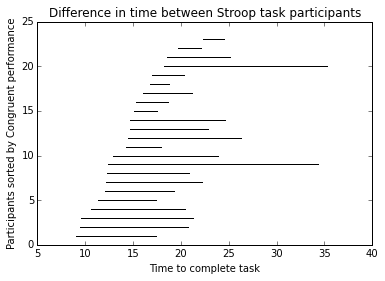

```python
%pylab inline

import matplotlib.pyplot as plt

df_sorted = dataFrame.sort(columns='Congruent')

j = 0
for i in df_sorted['Congruent'].index:
	plt.plot([df_sorted['Congruent'][i], df_sorted['Incongruent'][i]], [j]*2, color = 'k')
	j = j+1

plt.xlabel("Time to complete task")
plt.ylabel("Participants sorted by Congruent performance")
plt.title("Difference in time between Stroop task participants")
plt.show()
```

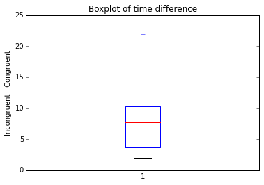

```python
plt.boxplot(dataFrame['Incongruent'] - dataFrame['Congruent'])
plt.ylabel("Incongruent - Congruent")
plt.title("Boxplot of time difference")
plt.show()
```

The above plots show that for every given particpant, their Incongruent time was always longer than their Congruent time. The increase in time is highly variable and does not have relationship to Congruent time. Most time increases were under 10 seconds.

#### 5. Now, perform the statistical test and report your results. What is your confidence level and your critical statistic value? Do you reject the null hypothesis or fail to reject it? Come to a conclusion in terms of the experiment task. Did the results match up with your expectations?

```python
import scipy.stats
scipy.stats.ttest_rel(dataFrame['Incongruent'], dataFrame['Congruent'], axis=0)
```

```
(8.020706944109957, 4.1030005857111781e-08)
```

We perform a paired t-test to evaluate if there is a difference between the times it takes to complete the two tasks. From the results of this test, we find that the test statistic is 8.021.

```python
# calculating critical value
df_diff = dataFrame['Incongruent'] - dataFrame['Congruent']
mean_diff = df_diff.mean()
std_diff = df_diff.std()
n = df_diff.count()
df = n - 1
alpha = 0.01
t_critical = scipy.stats.t.ppf(1-alpha,df)

print "mean difference is:", mean_diff
print "standard deviation of difference is:", std_diff
print "critical value for t-test with", alpha,"level of confidence and", df, "degrees of freedom:", t_critical
```

```
mean difference is: 7.96479166667
standard deviation of difference is: 4.86482691036
critical value for t-test with 0.01 level of confidence and 23 degrees of freedom: 2.49986673949
```

For a one sided 1% confidence level, the critical value is about 2.5. The t-statistic from our test gives a value of 8.02. Since our t-statistic is greater than the critical value, we reject the null hypothesis at 1% confidence level.

We can then say that we observe significantly increased times to complete incongruent tasks versus congruent tasks.

#### 6. Optional: What do you think is responsible for the effects observed? Can you think of an alternative or similar task that would result in a similar effect? Some research about the problem will be helpful for thinking about these two questions!